# Lista de exercícios 2 - Métodos Computacionais Aplicados

WILLIAM BRUNO SALES DE PAULA LIMA - 497345, MARCOS VINICIUS ANDRADE DE SOUSA - 496788

# Questão 1

Utilize os pacotes “PNADcIBGE”, “survey” e “dplyr” para importar e manipular os dados da PNAD Contínua, referentes ao primeiro trimestre de 2023. Em seguida, obtenha as informações a seguir:

## Importação de bibliotecas

Código “set it and forget it” para que a instalação de libs funcione fora do RStudio:

```r
options(repos='http://cran.rstudio.com/')
```

Instalando as bibliotecas necessárias:

```r
install.packages("PNADcIBGE")
install.packages("survey")
install.packages("dplyr")
```

Carregando as bibliotecas:

```r
library(PNADcIBGE)
library(survey)
library(dplyr)
```

Obtendo dados da PNADc referentes ao primeiro trimestre de 2023:

```r
dadosPNADc <- get_pnadc(year = 2023, quarter = 1,
                        labels=TRUE, deflator=TRUE,
                        design=TRUE, savedir=tempdir())
```

Agora, com os dados carregados, vamos calcular o item a:

1. O percentual de pessoas ocupadas por sexo;

```r
totalsexo <- svyratio(~V2007, dadosPNADc, na.rm = T)
totalsexo
```

2. O rendimento médio mensal por sexo;

```r
rendimentoporsexo <- svyby(~VD4020, ~V2007, dadosPNADc, svymean, na.rm = T)
rendimentoporsexo
```

3. A distribuição de pessoas desocupadas por faixa etária (14 a 17 anos, 18 a 24 anos, 25 a 39 anos, 40 a 59 anos, 60 anos ou mais);

Primeiro, vamos transformar todas as faixas etárias em uma única variável chamada idade:

```r
dadosPNADc<-update(dadosPNADc, Idade = case_when(
  V2009 %in% 14:17 ~ "14-17",
  V2009 %in% 18:24 ~ "18-24",
  V2009 %in% 25:39 ~ "25-39",
  V2009 %in% 40:59 ~ "40-59",
  V2009 > 59 ~ "60+")
)
```

Agora, vamos calcular a distribuição de pessoas desocupadas por faixa etária:

```r
perc_desoc_faixa_etaria <- svyby(~Idade, ~VD4002, dadosPNADc, svymean, na.rm = T)
perc_desoc_faixa_etaria
```

4. O rendimento médio mensal por faixa etária;

```r
rendimento_por_faixa_etaria <- svyby(~VD4020, ~Idade, dadosPNADc, svymean, na.rm = T)
rendimento_por_faixa_etaria
```

# Questão 2

```r
soma_e_divide_por_dois <- function(x, y) {
  result <- (x + y) / 2
  return(result)
}

num1 <- 10
num2 <- 5

result <- soma_e_divide_por_dois(num1, num2)
print(result)
```

# Questão 3

As taxas de aluguel são influenciadas pela população de estudantes em uma cidade onde há universidades? Seja rent o aluguel médio mensal pago pela unidade alugada em uma determinada cidade, onde há universidades. Seja pop o total da população da cidade, avginc, a renda média da cidade e pctstu, a população de estudantes como um percentual da população total. Um modelo para testar uma relação é:

log (rent) = B0 + B1 * log(pop) + B2 * log(avginc) + B3 * pctstu + u

Responda:

1. Quais sinais você espera para B1 e B2?

Espero que os sinais dos parâmetros sejam ambos positivos, pois acredito que quanto maior a população e a renda média da cidade, maior será o aluguel médio mensal pago pela unidade alugada.

2. Estime o modelo acima, a partir da base de dados de 1990 de 64 cidades com universidades do arquivo RENTAL.dta (Stata).

```r
install.packages("haven")
library(haven)
```

```r
# Lendo o arquivo .DTA e transformando em dataframe
rental_data <- read_dta("lista_2/data/RENTAL.DTA")

# Checando as primeiras linhas do dataframe
head(rental_data)

# Ajustando modelo de regressão linear
model <- lm(log(rent) ~ log(pop) + log(avginc) + pctstu, data = rental_data)

# Print a summary of the regression model
summary(model)
```

3. Interprete os resultados estimados (Significância global, individual, R quadrado (R-squared) e coerência dos sinais).

Abaixo seguem os resultados obtidos na construção do modelo:

Residual standard error: 0.1517 on 124 degrees of freedom Multiple R-squared: 0.7971, Adjusted R-squared: 0.7922 F-statistic: 162.4 on 3 and 124 DF, p-value: < 2.2e-16

O modelo apresenta um R-squared de 0.7971, o que significa que 79.71% da variância da variável dependente (log(rent)) é explicada pelas variáveis independentes (log(pop), log(avginc) e pctstu). O modelo também apresenta um F-statistic de 162.4, o que significa que o modelo é estatisticamente significativo. Além disso, os sinais dos parâmetros são coerentes com o esperado, pois todos são positivos.

4. O que está errado com a seguinte afirmação: “Um aumento de 10% na população está associado a um aumento de cerca de 6,6% no aluguel”?

O que está errado é que o modelo utiliza transformações logarítimicas tanto na variável dependente, quanto nas variáveis independentes, ou seja, os parâmetros são elásticidades.

5. O modelo é globalmente ajustado? Justifique.

Sim, pois o modelo apresenta um F-statistic de 162.4, o que significa que o modelo é estatisticamente significativo.

# Questão 4

O arquivo nerlove.xlsx contém dados sobre os custos de produção, quantidade produzida e insumos para 145 empresas de energia elétrica. Os dados são para os EUA e foram coletados por M. Nerlove. As observações estão na linha, e nas colunas estão as variáveis: CUSTO (TC), PRODUTO (Q), PREÇO DO TRABALHO (PL), PREÇO DO COMBUSTÍVEL (PF) e PREÇO DO CAPITAL (PK) das companhias. Observe que os dados são classificados por nível de produto (a segunda coluna). Estime o modelo Cobb-Douglas:

Observação: Use o Rstudio para importar a base de dados. Em seguida criar as variáveis em logaritmo e acrescentar ao dataframe original para, em seguida, realizar a estimação.

```r
# Carregando a biblioteca
install.packages("readxl")
```

```
Error in install.packages : Updating loaded packages
```

```r
library(readxl)
```

```r
# Lendo o arquivo nerlove.xlsx
dados <- read_excel("data/nerlove.xlsx")

# Vizualizando os dados
print(dados)
```

| TC | Q | PL | PF | PK |
| --- | --- | --- | --- | --- |
| 0.082 | 2 | 2.1 | 17.9 | 183 |
| 0.661 | 3 | 2.1 | 35.1 | 174 |
| 0.990 | 4 | 2.1 | 35.1 | 171 |
| 0.315 | 4 | 1.8 | 32.2 | 166 |
| 0.197 | 5 | 2.1 | 28.6 | 233 |
| 0.098 | 9 | 2.1 | 28.6 | 195 |
| 0.949 | 11 | 2.0 | 35.5 | 206 |
| 0.675 | 13 | 2.1 | 35.1 | 150 |
| 0.525 | 13 | 2.2 | 29.1 | 155 |
| 0.501 | 22 | 1.7 | 15.0 | 188 |

[output cut: 135 more lines]

```r
# Ajuste do modelo Cobb-Douglas
modelo <- lm(log(TC) ~ log(Q) + log(PL) + log(PF) + log(PK), data = dados)

# Exibir os resultados
summary(modelo)
```

```
Call:
lm(formula = log(TC) ~ log(Q) + log(PL) + log(PF) + log(PK),
    data = dados)

Residuals:
     Min       1Q   Median       3Q      Max
-0.97203 -0.23377 -0.01091  0.16185  1.80985

Coefficients:
            Estimate Std. Error t value Pr(>|t|)
(Intercept) -3.56651    1.77938  -2.004    0.047 *
log(Q)       0.72091    0.01743  41.352  < 2e-16 ***
log(PL)      0.45596    0.29980   1.521    0.131
log(PF)      0.42581    0.10032   4.244 3.97e-05 ***
log(PK)     -0.21515    0.33983  -0.633    0.528
---
Signif. codes:  0 ‘***’ 0.001 ‘**’ 0.01 ‘*’ 0.05 ‘.’ 0.1 ‘ ’ 1

Residual standard error: 0.3923 on 140 degrees of freedom
Multiple R-squared:  0.926, Adjusted R-squared:  0.9239
F-statistic: 437.9 on 4 and 140 DF,  p-value: < 2.2e-16
```

1. Interprete os resultados obtidos (Significância global, individual, R² e coerência dos sinais).

```r
# Interpretação da significância global
summary(modelo)$fstatistic
```

```
   value    numdf    dendf
437.9038   4.0000 140.0000
```

```r
# Interpretação da significância individual
summary(modelo)$coefficients[, "Pr(>|t|)"]
```

```
 (Intercept)       log(Q)      log(PL)      log(PF)      log(PK)
4.696105e-02 2.356900e-80 1.305440e-01 3.966429e-05 5.276981e-01
```

```r
# Interpretação dos coeficientes
summary(modelo)$coefficients[, "Estimate"]
```

```
(Intercept)      log(Q)     log(PL)     log(PF)     log(PK)
 -3.5665126   0.7209135   0.4559645   0.4258138  -0.2151477
```

```r
# Interpretação do R²
summary(modelo)$r.squared
```

```
[1] 0.9259892
```

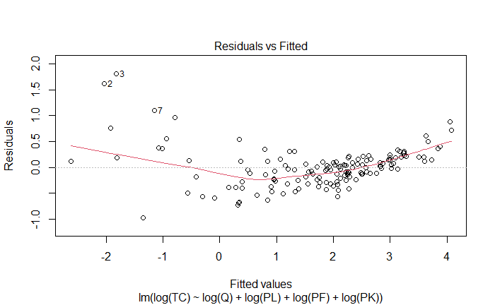

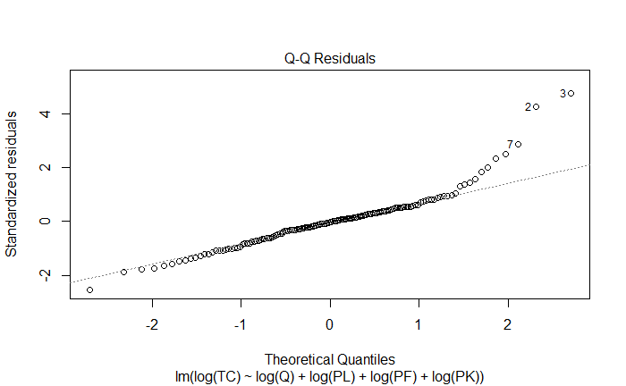

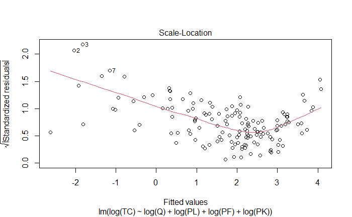

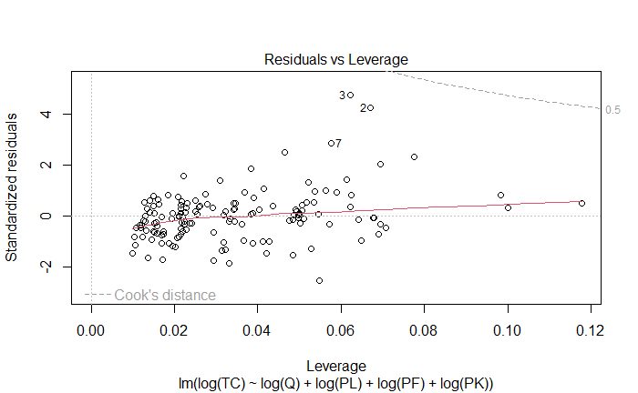

```r
# Diagnósticos de resíduos
plot(modelo)
```

2. O modelo é globalmente ajustado? Justifique.

0 modelo é globalmente ajustado, pois o R² justado é 0.9238746 de 1.

```r
# Exemplo de interpretação do R^2 ajustado
r_squared_adj <- summary(modelo)$adj.r.squared

print(r_squared_adj)
```

```
[1] 0.9238746
```

3. Use o pacote rgl para esboçar um Gráfico 3D com as variáveis PREÇO DO CAPITAL (PK), PREÇO DO TRABALHO (PL) e PREÇO DO COMBUSTÍVEL (PF).

```r
install.packages("rgl")
library(rgl)
```

```r
# Gráfico 3D
with(dados, plot3d(PK, PL, PF, col = "blue", size = 3))
axes3d(labels = c("PREÇO DO CAPITAL (PK)", "PREÇO DO TRABALHO (PL)", "PREÇO DO COMBUSTÍVEL (PF)"))
```

[output not shown]

4. Analise a coerência dos sinais dos estimadores. O coeficiente associado a log(Q) é positivo, isso indica uma relação positiva entre a quantidade produzida e o custo total. Assim como o PL e PF, eles tem coenficientes positivos, logo isso indica uma relação positiva entre cada uma dessas variáveis e o custo total. Contudo, o PK é negativo, e isso indica uma relação negativa entre ele e o custo total.

```r
summary(modelo)
```

# Questão 5

A análise de regressão pode ser usada para testar se o mercado usa eficientemente as informações ao avaliar ações. Seja return etorno total de possuir ações de uma empresa ao longo de um período de quatro anos, do final de 1990 até o final de 1994. A hipótese dos mercados eficientes diz que esses retornos não devem estar sistematicamente relacionados à informação conhecida em 1990. Se as características conhecidas da empresa no início do período ajudassem a prever os retornos das ações, poderíamos usar essas informações para escolher ações.

Para 1990, seja dkr relação dívida-capital de uma empresa, seja eps os ganhos por ação, seja netinc a renda líquida e seja salary emuneração total dos CEOs da empresa.

```r
# Instalando Haven
install.packages("haven")
library(haven)
```

```r
# Lendo return.dta
dados <- read_dta("data/RETURN.DTA")

print(dados)
```

| roe | rok | dkr | eps | netinc | sp90 | sp94 | salary | return | lsalary | lsp90 | lnetinc |
| --- | --- | --- | --- | --- | --- | --- | --- | --- | --- | --- | --- |
| 18.7 | 17.4 | 4.0 | 48.1 | 1144 | 59.375 | 47.000 | 1090 | -20.8421059 | 6.993933 | 4.083873 | 7.042286 |
| 1.6 | 2.4 | 27.3 | -85.3 | 35 | 47.875 | 43.500 | 1923 | -9.1383810 | 7.561642 | 3.868593 | 3.555348 |
| 4.9 | 4.6 | 36.8 | -44.1 | 127 | 39.000 | 72.625 | 1012 | 86.2179489 | 6.919684 | 3.663562 | 4.844187 |
| 11.1 | 8.6 | 46.4 | 192.4 | 367 | 61.250 | 142.000 | 579 | 131.8367310 | 6.361302 | 4.114964 | 5.905362 |
| 5.6 | 4.5 | 36.2 | -60.4 | 214 | 58.000 | 53.250 | 600 | -8.1896553 | 6.396930 | 4.060443 | 5.365976 |
| 3.5 | 2.9 | 18.7 | -79.8 | 118 | 68.250 | 50.500 | 735 | -26.0073261 | 6.599871 | 4.223177 | 4.770685 |
| 12.3 | 8.5 | 34.4 | 39.0 | 175 | 33.000 | 50.250 | 994 | 52.2727280 | 6.901737 | 3.496508 | 5.164786 |
| 7.5 | 6.3 | 57.8 | -62.8 | 1692 | 43.625 | 27.875 | 1227 | -36.1031532 | 7.112328 | 3.775630 | 7.433667 |
| 15.6 | 10.5 | 33.4 | -16.2 | 157 | 42.750 | 44.250 | 913 | 3.5087719 | 6.816736 | 3.755369 | 5.056246 |
| 12.5 | 9.4 | 33.4 | -19.1 | 315 | 37.125 | 47.750 | 733 | 28.6195278 | 6.597146 | 3.614291 | 5.752573 |

[output cut: 132 more lines]

1. Usando os dados do arquivo RETURN.dta, estime e interprete o modelo: # return = b0 + b1*dkr + b2*eps + b3*netinc + b4*salary + u

```r
# Estimar o modelo
modelo <- lm(return ~ dkr + eps + netinc + salary, data = dados)

# Resumo do modelo
summary(modelo)
```

```
Call:
lm(formula = return ~ dkr + eps + netinc + salary, data = dados)

Residuals:
    Min      1Q  Median      3Q     Max
-88.629 -25.421  -4.215  18.326 124.627

Coefficients:
              Estimate Std. Error t value Pr(>|t|)
(Intercept) -14.370216   6.893616  -2.085    0.039 *
dkr           0.320544   0.200911   1.595    0.113
eps           0.042699   0.078138   0.546    0.586
netinc       -0.005109   0.004675  -1.093    0.276
salary        0.003499   0.002194   1.595    0.113
---
Signif. codes:  0 ‘***’ 0.001 ‘**’ 0.01 ‘*’ 0.05 ‘.’ 0.1 ‘ ’ 1

Residual standard error: 39.19 on 137 degrees of freedom
Multiple R-squared:  0.03948,   Adjusted R-squared:  0.01143
F-statistic: 1.408 on 4 and 137 DF,  p-value: 0.2347
```

2. As variáveis explicativas são conjuntamente significantes ao nível de 5%? Alguma variável explicativa é individualmente significante?

```r
# Teste F para a significância global das variáveis explicativas
anova_global <- anova(modelo)

print(anova_global)
```

```
Analysis of Variance Table

Response: return
           Df Sum Sq Mean Sq F value Pr(>F)
dkr         1   3079  3078.9  2.0043 0.1591
eps         1    608   607.9  0.3958 0.5303
netinc      1   1053  1053.2  0.6856 0.4091
salary      1   3909  3909.3  2.5449 0.1130
Residuals 137 210447  1536.1
```

3. Agora estime o modelo anterior usando a forma log para netinc e salary: # return = b0 + b1*dkr + b2*eps + b3*log(netinc) + b4*log(salary) + u Alguma de suas conclusões no item (a) mudou?

```r
# Aplicar log nas variáveis netinc e salary
dados$log_netinc <- log(dados$netinc)
dados$log_salary <- log(dados$salary)

# Estimar o modelo com a forma log
modelo_log <- lm(return ~ dkr + eps + log_netinc + log_salary, data = dados)

# Resumo do modelo com a forma log
summary(modelo_log)
```

```
Call:
lm(formula = return ~ dkr + eps + log_netinc + log_salary, data = dados)

Residuals:
    Min      1Q  Median      3Q     Max
-80.402 -26.729  -4.223  19.475 126.948

Coefficients:
             Estimate Std. Error t value Pr(>|t|)
(Intercept) -36.29934   39.37380  -0.922    0.358
dkr           0.32658    0.20265   1.612    0.109
eps           0.06854    0.08035   0.853    0.395
log_netinc   -4.74530    3.38566  -1.402    0.163
log_salary    7.24181    6.31251   1.147    0.253

Residual standard error: 39.32 on 137 degrees of freedom
Multiple R-squared:  0.03304,   Adjusted R-squared:  0.004812
F-statistic:  1.17 on 4 and 137 DF,  p-value: 0.3266
```

```r
# Estimar o modelo com a forma log
modelo_log <- lm(return ~ dkr + eps + log_netinc + log_salary, data = dados)

# Resumo do modelo com a forma log
resumo_modelo <- summary(modelo_log)

# Obter o R² ajustado
r_squared_ajustado <- resumo_modelo$adj.r.squared

# Imprimir o R² ajustado
print(r_squared_ajustado)
```

```
[1] 0.004811835
```